# Data Science Capstone: Milestone Report

Utkarsh Chauhan

9/21/2020

## Introduction

This is the Milestone Report for the Coursera Data Science Capstone project. The goal of the capstone project is to create a predictive text model using a large text corpus of documents as training data. Natural language processing techniques will be used to perform the analysis and build the predictive model.  
This milestone report describes the major features of the training data with our exploratory data analysis and summarizes our plans for creating the predictive model.

## Loading Data

Libraries needed :

```r
library(NLP)
library(tm)
library(RWeka)
library(readr)
library(ggplot2)
```

Downloading and loading data :

```r
if ( !file.exists("Coursera-SwiftKey.zip") ) {
    download.file('https://d396qusza40orc.cloudfront.net/dsscapstone/dataset/Coursera-SwiftKey.zip',
                  'Coursera-SwiftKey.zip')
}

unzip('Coursera-SwiftKey.zip', list = TRUE)
```

```
##                             Name    Length                Date
## 1                         final/         0 2014-07-22 10:10:00
## 2                   final/de_DE/         0 2014-07-22 10:10:00
## 3  final/de_DE/de_DE.twitter.txt  75578341 2014-07-22 10:11:00
## 4    final/de_DE/de_DE.blogs.txt  85459666 2014-07-22 10:11:00
## 5     final/de_DE/de_DE.news.txt  95591959 2014-07-22 10:11:00
## 6                   final/ru_RU/         0 2014-07-22 10:10:00
## 7    final/ru_RU/ru_RU.blogs.txt 116855835 2014-07-22 10:12:00
## 8     final/ru_RU/ru_RU.news.txt 118996424 2014-07-22 10:12:00
## 9  final/ru_RU/ru_RU.twitter.txt 105182346 2014-07-22 10:12:00
## 10                  final/en_US/         0 2014-07-22 10:10:00
## 11 final/en_US/en_US.twitter.txt 167105338 2014-07-22 10:12:00
## 12    final/en_US/en_US.news.txt 205811889 2014-07-22 10:13:00
## 13   final/en_US/en_US.blogs.txt 210160014 2014-07-22 10:13:00
## 14                  final/fi_FI/         0 2014-07-22 10:10:00
## 15    final/fi_FI/fi_FI.news.txt  94234350 2014-07-22 10:11:00
## 16   final/fi_FI/fi_FI.blogs.txt 108503595 2014-07-22 10:12:00
## 17 final/fi_FI/fi_FI.twitter.txt  25331142 2014-07-22 10:10:00
```

This is the list of files we got from our data. The data sets consist of text from 3 different sources:  
1. News  
2. Blogs  
3. Twitter  
The text data are provided in 4 different languages:  
1) German, 2) English - United States, 3) Finnish and 4) Russian.  
In this report, we will only focus on the English - United States data sets.

```r
blogs <- read_lines("final/en_US/en_US.blogs.txt", skip_empty_rows = TRUE)
news <- read_lines("final/en_US/en_US.news.txt", skip_empty_rows = TRUE)
twitter <- read_lines("final/en_US/en_US.twitter.txt", skip_empty_rows = TRUE)
```

Words for profanity filtering are taken from [Luis von Ahn’s](https://www.cs.cmu.edu/~biglou) Research Group.

```r
if (!file.exists('bad-words.txt')) {
    download.file('https://www.cs.cmu.edu/~biglou/resources/bad-words.txt','bad-words.txt')
}
badwords <- read_lines('bad-words.txt',skip_empty_rows = TRUE)
```

Lets examine our data :

```r
sb <- file.size("final/en_US/en_US.blogs.txt")
sn <- file.size("final/en_US/en_US.news.txt")
st <- file.size("final/en_US/en_US.twitter.txt")

data.frame(source = c("blogs", "news", "twitter"),
           size.MB = c(sb/1024, sn/1024, st/1024),
           num.lines = c(NROW(blogs),NROW(news),NROW(twitter)),
           num.char = c(sum(nchar(blogs)),sum(nchar(news)),sum(nchar(twitter))))
```

```
##    source  size.MB num.lines  num.char
## 1   blogs 205234.4    899288 206824505
## 2    news 200988.2   1010242 203223159
## 3 twitter 163188.8   2360148 162096031
```

## Cleaning and Sampling

Since our raw data is huge, we will use a sample of it for analysis :

```r
set.seed(3339)

blogs <- blogs[sample(length(blogs),25000)]
news <- news[sample(length(news),25000)]
twitter <- twitter[sample(length(twitter),25000)]
```

Cleaning involves removing URLs, special characters, punctuations, numbers, excess white space, stop words, and changing the text to lower case.

```r
corp <- VCorpus(VectorSource(c(blogs,news,twitter)))
remove(blogs,news,twitter)      ## removing lists as we dont need them now
corp <- tm_map(corp, content_transformer(tolower))
## for removing pattern of choice
rem <- content_transformer(function(x, pattern) gsub(pattern, " ", x))
corp <- tm_map(corp, rem, "(f|ht)tp(s?)://(.*)[.][a-z]+")
corp <- tm_map(corp, rem, "@[^\\s]+")
corp <- tm_map(corp, removeNumbers)
corp <- tm_map(corp,removePunctuation)
corp <- tm_map(corp,removeWords, badwords)
corp <- tm_map(corp,removeWords, stopwords())
corp <- tm_map(corp, stripWhitespace)
```

## N-Gram Tokenization

Lets create unigram, bigram, and trigram tokenizers.

```r
BigramTokenizer <- function(x) NGramTokenizer(x, Weka_control(min = 2, max = 2))
TrigramTokenizer <- function(x) NGramTokenizer(x, Weka_control(min = 3, max = 3))

TDM1 <- TermDocumentMatrix(corp, control = list(stemming=TRUE)) ## will create a unigram.
TDM2 <- TermDocumentMatrix(corp, control = list(tokenize = BigramTokenizer, stemming=TRUE))
TDM3 <- TermDocumentMatrix(corp, control = list(tokenize = TrigramTokenizer, stemming=TRUE))

inspect(TDM1)
```

```
## <<TermDocumentMatrix (terms: 68985, documents: 75000)>>
## Non-/sparse entries: 1062130/5172812870
## Sparsity           : 100%
## Maximal term length: 99
## Weighting          : term frequency (tf)
## Sample             :
##       Docs
## Terms  12463 13204 16931 21628 24453 27458 5273 5358 7255 9870
##   can      4     0     1     1     0     0    0    1    1    3
##   get      0     0     1     0     1     0    0    2    0    0
##   just     1     0     0     0     1     0    1    0    0    1
##   like     0     0     1     0     1     0    0    1    0    2
##   make     0     1     2     3     0     0    1    0    1    2
##   one      0     4     1     1     0     0    3    1    0    0
##   said     0     0     0    12     0     0    0    0    0    2
##   time     0     2     0     1     1     0    1    0    0    0
##   will    30     0     2     3     0     0    0    1    1    1
##   year     1     0     0     2     0     0    2    0    1    1
```

```r
inspect(TDM2)
```

```
## <<TermDocumentMatrix (terms: 843973, documents: 75000)>>
## Non-/sparse entries: 1115563/63296859437
## Sparsity           : 100%
## Maximal term length: 79
## Weighting          : term frequency (tf)
## Sample             :
##              Docs
## Terms         12463 13204 16931 21628 24453 27458 5273 5358 7255 9870
##   dont know       0     0     0     0     0     0    0    0    0    0
##   feel lik        0     0     0     0     0     0    0    0    0    0
##   first tim       0     0     0     0     0     0    0    0    0    0
##   high school     0     0     0     0     0     0    0    0    0    0
##   last night      0     0     0     0     0     0    0    0    0    0
##   last week       0     0     0     0     0     0    0    0    0    0
##   last year       0     0     0     0     0     0    0    0    0    0
##   new york        0     0     0     0     0     0    0    0    0    2
##   right now       0     0     0     0     0     0    0    0    0    0
##   years ago       0     0     0     0     0     0    0    0    0    0
```

```r
inspect(TDM3)
```

```
## <<TermDocumentMatrix (terms: 1034134, documents: 75000)>>
## Non-/sparse entries: 1051014/77558998986
## Sparsity           : 100%
## Maximal term length: 85
## Weighting          : term frequency (tf)
## Sample             :
##                         Docs
## Terms                    12463 13204 16931 21628 24453 27458 5273 5358 7255
##   cant wait se               0     0     0     0     0     0    0    0    0
##   cinco de mayo              0     0     0     0     0     0    0    0    0
##   first time sinc            0     0     0     0     0     0    0    0    0
##   happy mothers day          0     0     0     0     0     0    0    0    0
##   happy new year             0     0     0     0     0     0    0    0    0
##   let us know                0     0     0     0     0     0    0    0    0
##   new york c                 0     0     0     0     0     0    0    0    0
##   new york tim               0     0     0     0     0     0    0    0    0
##   president barack obama     0     0     0     0     0     0    0    0    0
##   two years ago              0     0     0     0     0     0    0    0    0
##                         Docs
## Terms                    9870
##   cant wait se              0
##   cinco de mayo             0
##   first time sinc           0
##   happy mothers day         0
##   happy new year            0
##   let us know               0
##   new york c                1
##   new york tim              0
##   president barack obama    0
##   two years ago             0
```

## Exploratory Data Analysis

It be interesting and helpful to find the most frequently occurring words in the data.

```r
f1 <- findFreqTerms(TDM1,lowfreq =2500)
f2 <- findFreqTerms(TDM2, lowfreq = 100)
f3 <- findFreqTerms(TDM3, lowfreq = 10)
Unigramfreq <- sort(rowSums(as.matrix(TDM1[f1,])),decreasing = TRUE)
Unigramfreq <- data.frame(word=names(Unigramfreq),frequency=Unigramfreq)
Bigramfreq <- sort(rowSums(as.matrix(TDM2[f2,])),decreasing = TRUE)
Bigramfreq <- data.frame(word=names(Bigramfreq),frequency=Bigramfreq)
Trigramfreq <- sort(rowSums(as.matrix(TDM3[f3,])),decreasing = TRUE)
Trigramfreq <- data.frame(word=names(Trigramfreq),frequency=Trigramfreq)
```

Here are the most common unigrams, bigrams, and trigrams.

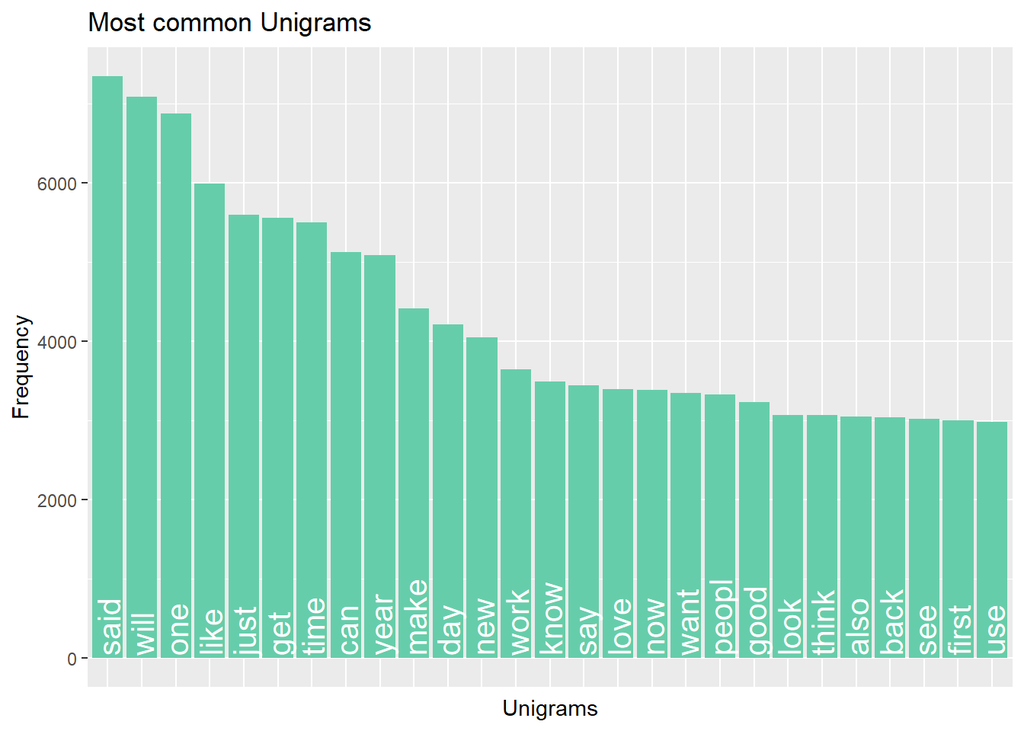

```r
g <- ggplot(Unigramfreq[1:27,], aes(x = factor(word,levels = Unigramfreq$word[1:27],
                                               ordered=TRUE), y = frequency)) +
    geom_bar(stat = "identity", fill='aquamarine3')
g + ggtitle("Most common Unigrams") + xlab("Unigrams") + ylab("Frequency") +
    geom_text(stat="count", y=30, hjust=0, size = 5.4, angle = 90,color='white',
              label=Unigramfreq[1:27,]$word) +
    theme(axis.text.x=element_blank(),axis.ticks.x=element_blank())
```

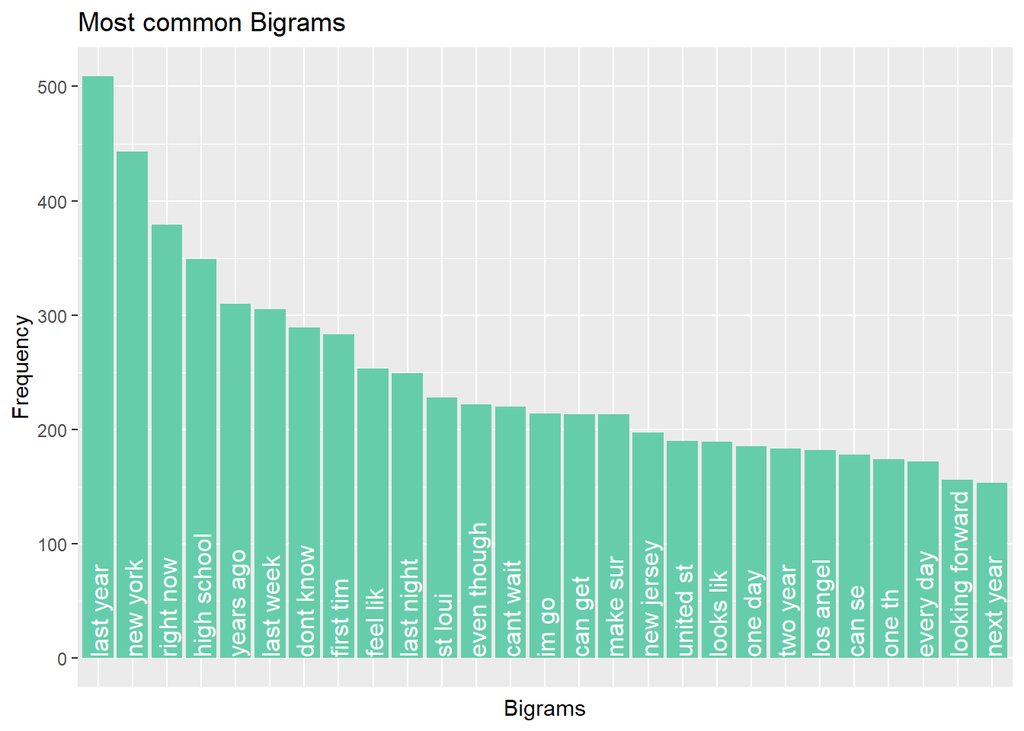

```r
g <- ggplot(Bigramfreq[1:27,], aes(x = factor(word,levels = Bigramfreq$word[1:27],
                                               ordered=TRUE), y = frequency)) +
    geom_bar(stat = "identity", fill='aquamarine3')
g + ggtitle("Most common Bigrams") + xlab("Bigrams") + ylab("Frequency") +
    geom_text(stat="count", y=0.9, hjust=0, size = 4.2, angle = 90,color='white',
              label=Bigramfreq[1:27,]$word) +
    theme(axis.text.x=element_blank(),axis.ticks.x=element_blank())
```

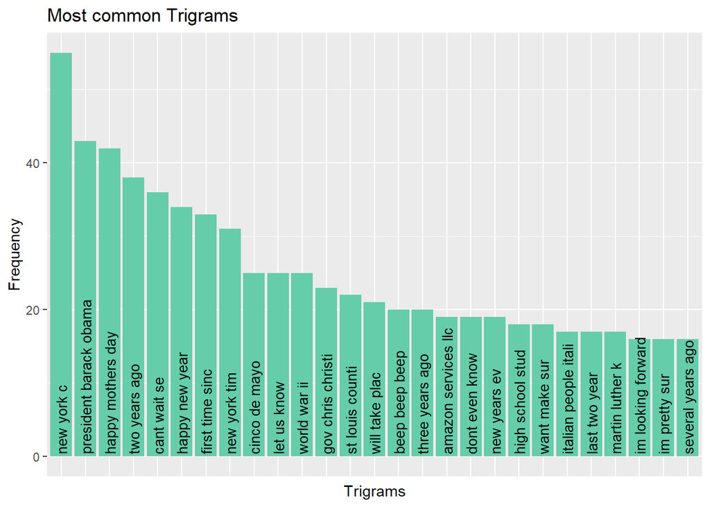

```r
g <- ggplot(Trigramfreq[1:27,], aes(x = factor(word,levels = Trigramfreq$word[1:27],
                                               ordered=TRUE), y = frequency)) +
    geom_bar(stat = "identity", fill='aquamarine3')
g + ggtitle("Most common Trigrams") + xlab("Trigrams") + ylab("Frequency") +
    geom_text(stat="count", y=0.3, hjust=0, size = 3.6, angle = 90,color='black',
              label=Trigramfreq[1:27,]$word) +
    theme(axis.text.x=element_blank(),axis.ticks.x=element_blank())
```

## Next Step

Our predictive algorithm will be using n-gram model with frequency similar to our exploratory analysis above. One possible strategy would be to use the trigram model to predict the next word. If no match is found, then the algorithm would back off to the bigram model, and then to the unigram model if needed.  
For the Shiny app, the plan is to create an app with a simple interface where the user can enter a string of text. Our prediction model will then give a list of suggested words for the next word.